# Sesión 4: Documentos dinámicos y Quarto

Métodos Cuantitativos para la Administración Pública

Autor/a

Cristóbal Mejías

Fecha de publicación

# 1 ¿Por qué documentos dinámicos?

En el trabajo cuantitativo, el flujo habitual consiste en correr código en R, copiar resultados a un procesador de texto, ajustar manualmente tablas y gráficos, y repetir el ciclo cada vez que algo cambia. Este proceso es lento, propenso a errores y dificulta la **reproducibilidad**: la capacidad de que cualquier persona pueda llegar exactamente a los mismos resultados a partir de los mismos datos y procedimientos.

Los **documentos dinámicos** resuelven este problema al integrar en un solo archivo el texto, el código y los resultados del análisis. Si los datos cambian, el documento se actualiza automáticamente al renderizarlo.

## 1.1 Reproducibilidad

La reproducibilidad es un principio central de la ciencia abierta. Un análisis es reproducible cuando:

- El código fuente está disponible y documentado.
- Los datos de entrada están accesibles o descritos con precisión.
- El entorno de trabajo (paquetes, versiones) está registrado.
- Cualquier persona puede llegar al mismo resultado siguiendo los mismos pasos.

## 1.2 Markdown vs. Quarto

| Concepto | Descripción |
| --- | --- |
| **Markdown** | Lenguaje de texto plano con marcas mínimas de formato (`.md`). Solo texto y estructura. |
| **R Markdown** | Extensión de Markdown que permite incluir código R ejecutable (`.Rmd`). Específico para R. |
| **Quarto** | Sistema moderno y multilenguaje (R, Python, Julia) para documentos dinámicos (`.qmd`). Estándar actual del curso. |

# 2 Sintaxis de Markdown

Todo el texto de un archivo `.qmd` se escribe en Markdown.

| Código | Resultado |
| --- | --- |
| `**negrita**` | **negrita** |
| `*cursiva*` | *cursiva* |
| `# Título 1` | Encabezado de nivel 1 |
| `## Título 2` | Encabezado de nivel 2 |
| `[texto](https://url.com)` | Enlace |
| `![alt](ruta/imagen.png)` | Imagen |
| `> cita` | Bloque de cita |
| `- ítem` | Lista no ordenada |
| `1. ítem` | Lista ordenada |

# 3 Chunks de código y sus opciones

Un **chunk** es un bloque de código R que Quarto ejecuta al renderizar. Se inserta con `Ctrl+Alt+I`.

## 3.1 Opciones principales

| Opción | Descripción |
| --- | --- |
| `echo` | Muestra u oculta el código fuente |
| `eval` | Ejecuta o no el código |
| `output` | Incluye o excluye los resultados |
| `warning` | Muestra u oculta advertencias |
| `message` | Muestra u oculta mensajes de carga |
| `include` | Control global: suprime código y resultados |
| `label` | Identifica el chunk para referencias cruzadas |
| `fig-cap` | Título para gráficos (`label: fig-...`) |
| `tbl-cap` | Título para tablas (`label: tbl-...`) |

### 3.1.1 Referencias cruzadas

Cuando asignamos un `label` a un chunk, podemos citarlo en el texto con `@`:

- Tablas: `#| label: tbl-nombre` → referencia con `@tbl-nombre`
- Gráficos: `#| label: fig-nombre` → referencia con `@fig-nombre`

# 4 De Documento a Presentación

Una ventaja clave de Quarto es que **el mismo archivo puede convertirse en distintos formatos** simplemente cambiando el YAML.

## 4.1 Cambiar el formato

**Documento HTML:**

```yaml
format: html
```

**Presentación RevealJS:**

```yaml
format: revealjs
```

## 4.2 Separar diapositivas

Los encabezados `#` y `##` crean diapositivas automáticamente. También se puede usar `---` para separar manualmente:

```markdown
## Primera diapositiva

Contenido aquí.

---

Nueva diapositiva sin título.
```

## 4.3 Opciones útiles de RevealJS

```yaml
format:
  revealjs:
    theme: simple
    slide-number: true
    incremental: true
```

# 5 Aplicación práctica: Estatus Social Subjetivo

## 5.1 Preparación

```r
library(pacman)
pacman::p_load(tidyverse, dplyr, sjmisc, sjPlot, ggplot2, kableExtra, parameters)

options(scipen = 999)
rm(list = ls())
```

## 5.2 Carga de datos

```r
load(url("https://github.com/cursos-metodos-facso/datos-ejemplos/raw/main/issp_2009_chile.RData"))

names(issp)
```

```
 [1] "sex"           "age"           "educyrs"       "income"
 [5] "topbot"        "pref_redis"    "perc_ineq"     "conflict_rp"
 [9] "conflict_wcmc" "conflict_mw"   "conflict_tb"
```

```r
glimpse(issp)
```

```
Rows: 1,505
Columns: 11
$ sex           <fct> 1, 1, 1, 2, 2, 1, 2, 1, 2, 1, 1, 2, 1, 1, 1, 1, 2, 2, 1,…
$ age           <dbl> 23, 33, 36, 65, 20, 19, 41, 42, 50, 47, 21, 55, 58, 35, …
$ educyrs       <dbl> 12, 13, 7, 6, 13, 13, 13, 10, 13, 22, 12, 6, 8, 10, 8, 1…
$ income        <dbl> 5, 5, 7, 3, 1, 5, 9, 1, 5, 10, 8, 1, 6, 6, 9, 9, 1, 4, 9…
$ topbot        <dbl> 5, 5, 5, 6, 6, 4, 5, 6, 4, 6, 4, 6, 4, 1, 3, 5, 2, 5, 4,…
$ pref_redis    <dbl> 1, 4, 5, 2, 5, 4, 4, 3, 4, 3, 4, 4, 4, 4, 4, 3, 4, 4, 4,…
$ perc_ineq     <dbl> 3, 5, 5, 4, 5, 4, 5, 5, 5, 4, 5, 2, 2, 4, 5, 2, 4, 4, 4,…
$ conflict_rp   <dbl> 4, 1, 4, 3, 3, 2, 2, 2, 3, 2, 3, 1, 1, 3, 2, 4, 3, 3, 2,…
$ conflict_wcmc <dbl> 3, 2, 4, 3, 3, 1, 3, 1, 3, 1, 2, 1, 3, 3, 1, 2, 2, 3, NA…
$ conflict_mw   <dbl> 1, 3, 4, 2, 4, 3, 3, 3, 3, 2, 3, 1, 4, 3, 2, 2, 2, 3, 3,…
$ conflict_tb   <dbl> 4, 1, 3, 3, 3, 2, 3, 2, 3, 1, 1, 2, 4, 3, 2, 4, 3, 4, 3,…
```

## 5.3 Tabla descriptiva

```r
sjmisc::descr(issp,
      show = c("label","range", "mean", "sd", "NA.prc", "n"))%>% # Selecciona estadísticos
      kable(.,"markdown") # Esto es para que se vea bien en quarto
```

Tabla 1: Estadísticos descriptivos de variables seleccionadas

|  | var | label | n | NA.prc | mean | sd | range |
| --- | --- | --- | --- | --- | --- | --- | --- |
| 10 | sex | Sexo | 1505 | 0.0000000 | 1.582060 | 0.4933842 | 1 (1-2) |
| 1 | age | Edad | 1505 | 0.0000000 | 46.561462 | 17.6353912 | 73 (18-91) |
| 6 | educyrs | Nivel educativo | 1451 | 3.5880399 | 10.762922 | 4.4097420 | 24 (1-25) |
| 7 | income | Decil ingreso | 1146 | 23.8538206 | 5.489529 | 2.8723002 | 9 (1-10) |
| 11 | topbot | Estatus social subjetivo | 1490 | 0.9966777 | 4.025503 | 1.6599884 | 9 (1-10) |
| 9 | pref_redis | Preferencia por redistribución | 1477 | 1.8604651 | 3.828030 | 0.8835747 | 4 (1-5) |
| 8 | perc_ineq | Percepción desigualdad | 1492 | 0.8637874 | 4.188338 | 0.8271374 | 4 (1-5) |
| 3 | conflict_rp | Conflictos: ricos - pobres | 1438 | 4.4518272 | 2.613352 | 0.8665370 | 3 (1-4) |
| 5 | conflict_wcmc | Conflictos: clase trabajadora - clase media | 1426 | 5.2491694 | 2.289621 | 0.8965377 | 3 (1-4) |
| 2 | conflict_mw | Conflictos: directivos - trabajadores | 1427 | 5.1827243 | 2.714085 | 0.8304120 | 3 (1-4) |
| 4 | conflict_tb | Conflictos: gente de arriba - gente de abajo | 1425 | 5.3156146 | 2.661754 | 0.9044854 | 3 (1-4) |

## 5.4 Modelo de regresión lineal

```r
modelo_1 <- lm(topbot ~ educyrs,          data = issp)
modelo_2 <- lm(topbot ~ educyrs + income, data = issp)
```

## 5.5 Tabla de regresión con sjPlot

```r
sjPlot::tab_model(
  modelo_1, modelo_2,
  show.ci     = FALSE,
  show.se     = TRUE,
  dv.labels   = c("Modelo 1", "Modelo 2"),
  pred.labels = c("(Intercepto)", "Educación (nivel educativo)", "Ingreso (decíles"),
  title       = "Variable dependiente: Estatus Social Subjetivo (1–10)"
)
```

Tabla 2: Modelos de regresión: Estatus Social Subjetivo

Variable dependiente: Estatus Social Subjetivo (1–10)

|  | Modelo 1 |  |  | Modelo 2 |  |  |
| --- | --- | --- | --- | --- | --- | --- |
| Predictors | Estimates | std. Error | p | Estimates | std. Error | p |
| (Intercepto) | 2.45 | 0.11 | **<0.001** | 2.14 | 0.13 | **<0.001** |
| Educación (nivel educativo) | 0.15 | 0.01 | **<0.001** | 0.12 | 0.01 | **<0.001** |
| Ingreso (decíles |  |  |  | 0.11 | 0.02 | **<0.001** |
| Observations | 1440 |  |  | 1099 |  |  |
| R<sup>2</sup> / R<sup>2</sup> adjusted | 0.162 / 0.161 |  |  | 0.190 / 0.189 |  |  |

## 5.6 Visualización

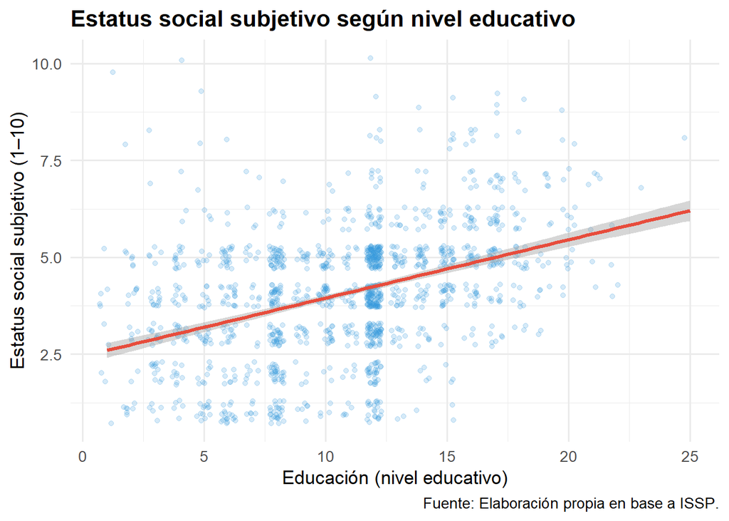

Figura 1: Relación entre educación y estatus social subjetivo

```r
ggplot(issp, aes(x = educyrs, y = topbot)) +
  geom_jitter(alpha = 0.2, color = "#3498db", width = 0.3, height = 0.3) +
  geom_smooth(method = "lm", se = TRUE, color = "#e74c3c", linewidth = 1.2) +
  labs(
    title   = "Estatus social subjetivo según nivel educativo",
    x       = "Educación (nivel educativo)",
    y       = "Estatus social subjetivo (1–10)",
    caption = "Fuente: Elaboración propia en base a ISSP."
  ) +
  theme_minimal(base_size = 13) +
  theme(plot.title = element_text(face = "bold"))
```

La Figura 1 muestra la asociación positiva entre años de escolaridad y el estatus percibido.

*Documento interno · MC FAGOB 2026 · Cristóbal Mejías*  
*Sesión 4 · 17 de abril de 2026*